# Chapter 9

[output not shown]

[output cut: 21 more lines]

[output not shown]

The aim of these exercises is to extend the analyses from Chapter 8, focusing on identifying the relative importance of predictors in linear models that include at least one continuous predictor.

## A

Recall the example of La Rosa and Conner (2017) from the Chapter 8 exercises. They examined effects of up to six floral traits on fitness components of milkweeds, *Asclepias* spp. The fitness components were male and female pollination success and female reproductive success.

```r
df <- read.csv("../data/larosa.csv")
head(df,10)
```

```
##    species plant.id gyn.width hood.length hood.height horn.reach slit.length
## 1     Asyr     AS01    0.2190      0.3557      0.5095     0.2038      0.1918
## 2     Asyr     AS02    0.2042      0.2776      0.5293     0.1820      0.1843
## 3     Asyr     AS03    0.2233      0.2771      0.5083     0.1809      0.1687
## 4     Asyr     AS04    0.2081      0.2403      0.4241     0.1520      0.1796
## 5     Asyr     AS05    0.2136      0.3544      0.5368     0.1940      0.1842
## 6     Asyr     AS07    0.2276      0.2984      0.4867     0.2161      0.1953
## 7     Asyr     AS08    0.2103      0.3155      0.4390     0.1806      0.1967
## 8     Asyr     AS09    0.2261      0.3385      0.5744     0.2101      0.1898
## 9     Asyr     AS10    0.2214      0.3508      0.5406     0.2295      0.1997
## 10    Asyr     AS11    0.2175      0.3166      0.4320     0.1501      0.1746
##    gap.width display.flowers.1day removals.per.flower insertions.per.flower
## 1     0.0464                  168              3.0308                0.3231
## 2     0.0597                  120              3.0732                1.0244
## 3     0.0664                  117              0.3226                0.1935
```

[output cut: 95 more lines]

```r
df_syr<-subset(df,species=="Asyr")
df_vir<-subset(df, species=='Avir')
df_tub<-subset(df, species=='Atub')
```

#### For each fitness component and for each species separately (i.e. 6 models in total):

**Refit the linear models from the Chapter 8 exercises but now use the recommended methods from this chapter (hierarchical partitioning or LMD, PMVD) to assess each predictor’s relative importance in each of the models.**

If you’re really keen, there’s a third species in the dataframe (*Atub*).

> We’ll only show the workings here for *A. syriaca* and the fitness component *removals per flower*. The same code can be run for the other combinations. We’ve used generic “asc.x” names for output frames, so to run other responses or species, it’s only necessary to edit the initial model asc.lm As a refresher, first run the model from Ch 8 again

```r
asc.lm<-lm(data=df_syr, removals.per.flower ~ gyn.width + hood.length + hood.height + horn.reach + slit.length + gap.width)
tidy(asc.lm)
```

```
## # A tibble: 7 × 5
##   term        estimate std.error statistic p.value
##   <chr>          <dbl>     <dbl>     <dbl>   <dbl>
## 1 (Intercept)     2.01      3.54     0.568 0.573
## 2 gyn.width     -18.9      15.1     -1.26  0.217
## 3 hood.length    12.9       4.96     2.60  0.0131
## 4 hood.height    13.8       4.76     2.90  0.00612
## 5 horn.reach    -10.9       7.09    -1.54  0.131
## 6 slit.length   -16.5      15.7     -1.05  0.299
## 7 gap.width     -28.0      14.2     -1.97  0.0556
```

```r
#Don't need to generate standardized coefficients, as predictors already standardized
std.coef(asc.lm, partial.sd=FALSE)
```

```
##             Estimate* Std. Error* df
## (Intercept)   0.00000     0.00000 38
## gyn.width    -0.18589     0.14793 38
## hood.length   0.44980     0.17281 38
## hood.height   0.50061     0.17243 38
## horn.reach   -0.30570     0.19830 38
## slit.length  -0.15913     0.15127 38
## gap.width    -0.27327     0.13838 38
```

```r
std.coef(asc.lm, partial.sd=TRUE)
```

```
##             Estimate* Std. Error* df
## (Intercept)   0.00000     0.00000 38
## gyn.width    -0.19769     0.15732 38
## hood.length   0.40947     0.15732 38
## hood.height   0.45674     0.15732 38
## horn.reach   -0.24252     0.15732 38
## slit.length  -0.16549     0.15732 38
## gap.width    -0.31067     0.15732 38
```

> Now get rel. importance

```r
asc.boot <- boot.relimp(asc.lm, b=1000, type = c("lmg", "pmvd"))
booteval.relimp(asc.boot)
```

```
## Response variable: removals.per.flower
## Total response variance: 1.45437
## Analysis based on 45 observations
##
## 6 Regressors:
## gyn.width hood.length hood.height horn.reach slit.length gap.width
## Proportion of variance explained by model: 33.87%
## Metrics are not normalized (rela=FALSE).
##
## Relative importance metrics:
##
##                    lmg       pmvd
## gyn.width   0.01744927 0.02774161
## hood.length 0.10802804 0.09437375
## hood.height 0.12134299 0.10386283
## horn.reach  0.02406247 0.03321906
## slit.length 0.01607970 0.02374381
## gap.width   0.05169171 0.05571311
##
## Average coefficients for different model sizes:
##
##                     1X        2Xs        3Xs        4Xs       5Xs       6Xs
## gyn.width    -5.529046 -10.149531 -13.064411 -15.080503 -16.90035 -18.93471
## hood.length   9.394187  10.080782  10.639191  11.238651  11.97681  12.90406
## hood.height   9.030463   9.906633  10.755746  11.665330  12.68560  13.82652
## horn.reach    4.084409   1.181650  -1.709401  -4.666682  -7.73801 -10.92311
## slit.length  -5.243806 -10.692791 -14.115228 -15.979426 -16.69027 -16.48079
## gap.width   -16.692283 -20.707933 -23.650220 -25.702443 -27.07967 -28.02496
##
##
##  Confidence interval information ( 1000 bootstrap replicates, bty= perc ):
## Relative Contributions with confidence intervals:
##
##                                    Lower  Upper
##                  percentage 0.95   0.95   0.95
## gyn.width.lmg    0.0174     ABCDEF 0.0020 0.1377
## hood.length.lmg  0.1080     ABCDEF 0.0105 0.2739
## hood.height.lmg  0.1213     ABCDE_ 0.0173 0.3093
## horn.reach.lmg   0.0241     _BCDEF 0.0127 0.0950
## slit.length.lmg  0.0161     ABCDEF 0.0036 0.1497
```

[output cut: 37 more lines]

```
## gyn.width-slit.length.pmvd    0.0040         -0.1479  0.1300
## gyn.width-gap.width.pmvd     -0.0280         -0.2089  0.0966
## hood.length-hood.height.pmvd -0.0095         -0.2705  0.2440
## hood.length-horn.reach.pmvd   0.0612         -0.0470  0.2659
## hood.length-slit.length.pmvd  0.0706         -0.1037  0.2809
## hood.length-gap.width.pmvd    0.0387         -0.1783  0.2509
## hood.height-horn.reach.pmvd   0.0706         -0.0392  0.2841
## hood.height-slit.length.pmvd  0.0801         -0.0704  0.2914
## hood.height-gap.width.pmvd    0.0481         -0.1209  0.2583
## horn.reach-slit.length.pmvd   0.0095         -0.1296  0.0989
## horn.reach-gap.width.pmvd    -0.0225         -0.2080  0.0801
## slit.length-gap.width.pmvd   -0.0320         -0.2034  0.1149
##
## * indicates that CI for difference does not include 0.
## CAUTION: Bootstrap confidence intervals can be somewhat liberal.
```

```r
glmm.hp(asc.lm, type="R2")
```

```
## $Total.R2
## [1] 0.3386542
##
## $hierarchical.partitioning
##             Unique Average.share Individual I.perc(%)
## gyn.width   0.0343       -0.0132     0.0211      5.38
## hood.length 0.0842        0.0061     0.0903     23.03
## hood.height 0.1852       -0.0219     0.1633     41.65
## horn.reach  0.0229        0.0021     0.0250      6.38
## slit.length 0.0217       -0.0066     0.0151      3.85
## gap.width   0.0873       -0.0100     0.0773     19.71
##
## $variables
## [1] "gyn.width"   "hood.length" "hood.height" "horn.reach"  "slit.length"
## [6] "gap.width"
##
## $type
## [1] "hierarchical.partitioning"
##
## attr(,"class")
## [1] "glmmhp"
```

**Now use AIC and Aikake weights to find the most parsimonious model (best fit with fewest predictors)** for each combination of fitness component and species. If there are multiple models with similar AICs, then use full (zero) model averaging to produce a final model.

```r
options(na.action = "na.fail")
asc.dredge <-dredge(asc.lm, beta="partial.sd", evaluate=TRUE)
```

```
## Fixed term is "(Intercept)"
```

```r
asc.dredge
```

```
## Global model call: lm(formula = removals.per.flower ~ gyn.width + hood.length +
##     hood.height + horn.reach + slit.length + gap.width, data = df_syr)
## ---
## Model selection table
##    (Int) gap.wdt  gyn.wdt hod.hgh hod.lng  hrn.rch  slt.lng df  logLik  AICc
## 32     0 -0.2949 -0.26150  0.4385  0.4111 -0.27330           7 -63.117 143.3
## 46     0 -0.3422           0.3739  0.3062          -0.27430  6 -64.542 143.3
## 30     0 -0.2847           0.3983  0.3666 -0.26490           6 -64.654 143.5
## 16     0 -0.3283 -0.25270  0.3514  0.3160                    6 -64.790 143.8
## 14     0 -0.3176           0.3102  0.2688                    5 -66.127 143.8
## 62     0 -0.3097           0.4352  0.3787 -0.22720 -0.23810  7 -63.387 143.8
## 6      0 -0.3023           0.4536                            4 -67.551 144.1
## 29     0                   0.3648  0.3692 -0.29990           5 -66.348 144.2
## 31     0         -0.25000  0.4029  0.4114 -0.30910           6 -65.053 144.3
## 38     0 -0.3210           0.5060                  -0.23190  5 -66.500 144.5
```

[output cut: 120 more lines]

```r
asc.ma<-model.avg(asc.dredge, beta="partial.sd")
summary(asc.ma)
```

```
##
## Call:
## model.avg(object = get.models(object = asc.dredge, subset = NA),
##     beta = "partial.sd")
##
## Component model call:
## lm(formula = removals.per.flower ~ <64 unique rhs>, data = df_syr)
##
## Component models:
##        df logLik   AICc delta weight
## 12345   7 -63.12 143.26  0.00   0.06
## 1346    6 -64.54 143.30  0.03   0.06
## 1345    6 -64.65 143.52  0.26   0.06
## 1234    6 -64.79 143.79  0.53   0.05
## 134     5 -66.13 143.79  0.53   0.05
## 13456   7 -63.39 143.80  0.54   0.05
## 13      4 -67.55 144.10  0.84   0.04
## 345     5 -66.35 144.23  0.97   0.04
## 2345    6 -65.05 144.32  1.05   0.04
## 136     5 -66.50 144.54  1.28   0.03
## 12346   7 -63.84 144.70  1.44   0.03
## 123456  8 -62.47 144.94  1.68   0.03
## 14      4 -68.00 145.01  1.75   0.03
## 4       3 -69.22 145.03  1.77   0.03
## 3       3 -69.23 145.05  1.79   0.03
## 34      4 -68.09 145.18  1.92   0.02
## 3456    6 -65.49 145.19  1.93   0.02
## 123     5 -66.85 145.23  1.97   0.02
## 346     5 -66.96 145.47  2.20   0.02
## 234     5 -67.00 145.55  2.29   0.02
## 36      4 -68.47 145.95  2.68   0.02
## 24      4 -68.57 146.15  2.89   0.02
## 124     5 -67.31 146.16  2.90   0.02
## 23      4 -68.64 146.28  3.02   0.01
## 135     5 -67.40 146.33  3.07   0.01
## 146     5 -67.40 146.34  3.08   0.01
## 23456   7 -64.67 146.37  3.10   0.01
## 46      4 -68.71 146.42  3.16   0.01
## 1236    6 -66.20 146.61  3.35   0.01
## 45      4 -68.88 146.76  3.50   0.01
```

[output cut: 46 more lines]

```
## hood.length  0.26965    0.21812     0.22097   1.220    0.222
## horn.reach  -0.09171    0.16394     0.16608   0.552    0.581
## slit.length -0.07982    0.14651     0.14873   0.537    0.592
##
## (conditional average)
##             Estimate Std. Error Adjusted SE z value Pr(>|z|)
## (Intercept)   0.0000     0.0000      0.0000     NaN      NaN
## gap.width    -0.3043     0.1659      0.1709   1.781   0.0749 .
## gyn.width    -0.2090     0.1705      0.1754   1.191   0.2335
## hood.height   0.3984     0.1745      0.1793   2.222   0.0263 *
## hood.length   0.3633     0.1734      0.1782   2.038   0.0415 *
## horn.reach   -0.2195     0.1905      0.1949   1.126   0.2600
## slit.length  -0.2081     0.1711      0.1760   1.182   0.2372
## ---
## Signif. codes:  0 '***' 0.001 '**' 0.01 '*' 0.05 '.' 0.1 ' ' 1
```

```r
confint(asc.ma)
```

```
##                   2.5 %     97.5 %
## (Intercept)  0.00000000 0.00000000
## gap.width   -0.63919132 0.03055412
## gyn.width   -0.55276461 0.13482585
## hood.height  0.04700925 0.74972116
## hood.length  0.01394504 0.71262105
## horn.reach  -0.60142039 0.16241017
## slit.length -0.55304809 0.13691380
```

```r
sw(asc.dredge)
```

```
##                      hood.height hood.length gap.width horn.reach gyn.width
## Sum of weights:      0.81        0.74        0.62      0.42       0.39
## N containing models:   32          32          32        32         32
##                      slit.length
## Sum of weights:      0.38
## N containing models:   32
```

## B

> How many exercises do we need for this chapter? Do we need BRT etc?

Dlugosz et al. (2013) might work; mammal exercise physiology, with model comparison approach. Only issue is that they use models fitted with OLS and two kinds of phylogenetically-adjusted model. Also took the approach of separating three taxa known to have unusual VO2 values by creating a new (binary) predictor for each species. The paper does look for effect sizes and discusses them in detail, so may not be bad, as long as we specify which variables students should use.

```r
library(readxl)
JEB088914TableS1 <- read_excel("../data/JEB088914TableS1.xls", skip = 1)
df<-dplyr::select(JEB088914TableS1, SPCode, Clade2, Diet1, N, MassG, VO2max, Wheel, MesquiteName)
(df <- df %>%
   mutate(PRONG = case_when(
     SPCode == 'AA' ~ 1,
     SPCode != 'AA' ~ 0
     )))
```

```
## # A tibble: 78 × 9
##    SPCode Clade2 Diet1     N    MassG  VO2max Wheel MesquiteName           PRONG
##    <chr>   <dbl> <dbl> <dbl>    <dbl>   <dbl> <dbl> <chr>                  <dbl>
##  1 DL         12     4    14     24.6    294.     1 DL_Dromiciops_gliroid…     0
##  2 MR         12     2     1  28500   304380      0 MR_Macropus_rufus          0
##  3 BP         12     2     2   1100    11664      0 BP_Bettongia_penicill…     0
##  4 CH         11     2     2  21150    65880      0 CH_Capra_hircus            0
##  5 CZ         11     2     6  18900    60102      0 CZ_Capra_aegagrus_hir…     0
##  6 OA         11     2     2  22650    63000      0 OA_Ovis_aries              0
##  7 CT         11     2     2  98000   261360      0 CT_Connochaetes_tauri…     0
##  8 GG         11     2     1  11200    36000      0 GG_Gazella_granti          0
##  9 MK         11     2     2   4354    14220      0 MK_Madoqua_kirkii          0
## 10 KD         11     2     2 114000   323280      0 KD_Kobus_defassa           0
## # ℹ 68 more rows
```

```r
(df <- df %>%
   mutate(HORSE = case_when(
     SPCode == 'EC' ~ 1,
     SPCode != 'EC' ~ 0
     )))
```

```
## # A tibble: 78 × 10
##    SPCode Clade2 Diet1     N    MassG  VO2max Wheel MesquiteName     PRONG HORSE
##    <chr>   <dbl> <dbl> <dbl>    <dbl>   <dbl> <dbl> <chr>            <dbl> <dbl>
##  1 DL         12     4    14     24.6    294.     1 DL_Dromiciops_g…     0     0
##  2 MR         12     2     1  28500   304380      0 MR_Macropus_ruf…     0     0
##  3 BP         12     2     2   1100    11664      0 BP_Bettongia_pe…     0     0
##  4 CH         11     2     2  21150    65880      0 CH_Capra_hircus      0     0
##  5 CZ         11     2     6  18900    60102      0 CZ_Capra_aegagr…     0     0
##  6 OA         11     2     2  22650    63000      0 OA_Ovis_aries        0     0
##  7 CT         11     2     2  98000   261360      0 CT_Connochaetes…     0     0
##  8 GG         11     2     1  11200    36000      0 GG_Gazella_gran…     0     0
##  9 MK         11     2     2   4354    14220      0 MK_Madoqua_kirk…     0     0
## 10 KD         11     2     2 114000   323280      0 KD_Kobus_defassa     0     0
## # ℹ 68 more rows
```

```r
(df <- df %>%
   mutate(BAT = case_when(
     SPCode == 'PH' ~ 1,
     SPCode != 'PH' ~ 0
     )))
```

```
## # A tibble: 78 × 11
##    SPCode Clade2 Diet1     N   MassG VO2max Wheel MesquiteName PRONG HORSE   BAT
##    <chr>   <dbl> <dbl> <dbl>   <dbl>  <dbl> <dbl> <chr>        <dbl> <dbl> <dbl>
##  1 DL         12     4    14  2.46e1 2.94e2     1 DL_Dromicio…     0     0     0
##  2 MR         12     2     1  2.85e4 3.04e5     0 MR_Macropus…     0     0     0
##  3 BP         12     2     2  1.1 e3 1.17e4     0 BP_Bettongi…     0     0     0
##  4 CH         11     2     2  2.11e4 6.59e4     0 CH_Capra_hi…     0     0     0
##  5 CZ         11     2     6  1.89e4 6.01e4     0 CZ_Capra_ae…     0     0     0
##  6 OA         11     2     2  2.27e4 6.30e4     0 OA_Ovis_ari…     0     0     0
##  7 CT         11     2     2  9.8 e4 2.61e5     0 CT_Connocha…     0     0     0
##  8 GG         11     2     1  1.12e4 3.60e4     0 GG_Gazella_…     0     0     0
##  9 MK         11     2     2  4.35e3 1.42e4     0 MK_Madoqua_…     0     0     0
## 10 KD         11     2     2  1.14e5 3.23e5     0 KD_Kobus_de…     0     0     0
## # ℹ 68 more rows
```

```r
df$lmass <- log10(df$MassG)
df$lVO2 <- log10(df$VO2max)
df$Clade2 <- as.character(df$Clade2)
df$Diet1 <- as.character(df$Diet1)
lm1 <-lm(data=df, lVO2 ~ lmass + Diet1 + Wheel + PRONG + BAT + HORSE)
summary(lm1)
```

```
##
## Call:
## lm(formula = lVO2 ~ lmass + Diet1 + Wheel + PRONG + BAT + HORSE,
##     data = df)
##
## Residuals:
##      Min       1Q   Median       3Q      Max
## -0.49872 -0.09628  0.00000  0.09387  0.52945
##
## Coefficients:
##             Estimate Std. Error t value Pr(>|t|)
## (Intercept)  1.52311    0.08404  18.124  < 2e-16 ***
## lmass        0.83393    0.01701  49.013  < 2e-16 ***
## Diet12      -0.28418    0.05925  -4.797 9.17e-06 ***
## Diet13      -0.24442    0.06455  -3.786 0.000326 ***
## Diet14      -0.20102    0.17647  -1.139 0.258635
## Diet15      -0.39907    0.17406  -2.293 0.024964 *
## Wheel       -0.01301    0.04851  -0.268 0.789441
## PRONG        0.76451    0.16802   4.550 2.27e-05 ***
## BAT          0.51806    0.16838   3.077 0.003014 **
## HORSE        0.60965    0.17151   3.555 0.000694 ***
## ---
## Signif. codes:  0 '***' 0.001 '**' 0.01 '*' 0.05 '.' 0.1 ' ' 1
##
## Residual standard error: 0.1641 on 68 degrees of freedom
## Multiple R-squared:  0.9843, Adjusted R-squared:  0.9823
## F-statistic: 474.7 on 9 and 68 DF,  p-value: < 2.2e-16
```

```r
library(lm.beta)
library(MuMIn)
options(na.action = "na.fail")
lm.dredge <- dredge(lm1, beta="none", evaluate=TRUE)
```

```
## Fixed term is "(Intercept)"
```

```r
lm.dredge
```

```
## Global model call: lm(formula = lVO2 ~ lmass + Diet1 + Wheel + PRONG + BAT + HORSE,
##     data = df)
## ---
## Model selection table
##    (Intrc)      BAT Diet1  HORSE  lmass  PRONG      Wheel df   logLik  AICc
## 32   1.513  0.52280     + 0.6074 0.8361 0.7647            10   35.587 -47.9
## 64   1.523  0.51810     + 0.6096 0.8339 0.7645 -0.0130100 11   35.628 -45.3
## 31   1.517              + 0.6106 0.8349 0.7666             9   30.366 -40.1
## 63   1.540              + 0.6156 0.8301 0.7661 -0.0287900 10   30.545 -37.8
## 28   1.467  0.52640     +        0.8489 0.7295             9   28.977 -37.3
## 60   1.471  0.52480     +        0.8481 0.7294 -0.0045160 10   28.981 -34.7
## 30   1.254  0.52000       0.5300 0.8454 0.6980             6   23.596 -34.0
## 62   1.259  0.51700       0.5312 0.8443 0.6978 -0.0070780  7   23.605 -31.6
## 27   1.471              +        0.8477 0.7312             8   24.468 -30.8
## 16   1.478  0.52560     + 0.5613 0.8459                    9   25.224 -29.8
```

[output cut: 120 more lines]

```r
lm.ma<-model.avg(lm.dredge)
summary(lm.ma)
```

```
##
## Call:
## model.avg(object = lm.dredge)
##
## Component model call:
## lm(formula = lVO2 ~ <64 unique rhs>, data = df)
##
## Component models:
##        df  logLik   AICc  delta weight
## 12345  10   35.59 -47.89   0.00   0.77
## 123456 11   35.63 -45.26   2.63   0.21
## 2345    9   30.37 -40.08   7.81   0.02
## 23456  10   30.54 -37.81  10.08   0.00
## 1245    9   28.98 -37.31  10.58   0.00
## 12456  10   28.98 -34.68  13.21   0.00
## 1345    6   23.60 -34.01  13.88   0.00
## 13456   7   23.60 -31.61  16.28   0.00
## 245     8   24.47 -30.85  17.04   0.00
## 1234    9   25.22 -29.80  18.09   0.00
## 145     5   19.70 -28.56  19.33   0.00
## 345     5   19.65 -28.46  19.43   0.00
## 2456    9   24.55 -28.44  19.45   0.00
## 12346  10   25.26 -27.24  20.65   0.00
## 3456    6   19.75 -26.32  21.57   0.00
## 1456    6   19.70 -26.21  21.68   0.00
## 234     8   21.12 -24.15  23.74   0.00
## 45      4   16.09 -23.63  24.26   0.00
## 124     8   20.76 -23.43  24.46   0.00
## 134     5   16.85 -22.86  25.03   0.00
## 2346    9   21.27 -21.90  25.99   0.00
## 456     5   16.14 -21.45  26.44   0.00
## 1246    9   20.76 -20.88  27.01   0.00
## 1346    6   16.86 -20.53  27.36   0.00
## 14      4   13.91 -19.28  28.61   0.00
## 34      4   13.53 -18.52  29.37   0.00
## 24      7   17.03 -18.47  29.42   0.00
## 146     5   13.91 -16.99  30.90   0.00
## 346     5   13.63 -16.42  31.47   0.00
## 246     8   17.11 -16.13  31.76   0.00
## 4       3   10.81 -15.30  32.59   0.00
```

[output cut: 51 more lines]

```
##
## (conditional average)
##             Estimate Std. Error Adjusted SE z value Pr(>|z|)
## (Intercept)  1.51451    0.07704     0.07839  19.319  < 2e-16 ***
## BAT          0.52184    0.16685     0.16984   3.073 0.002122 **
## Diet12      -0.28381    0.05905     0.06010   4.722  2.3e-06 ***
## Diet13      -0.24296    0.06425     0.06539   3.715 0.000203 ***
## Diet14      -0.20533    0.17488     0.17801   1.153 0.248721
## Diet15      -0.40002    0.17341     0.17651   2.266 0.023434 *
## HORSE        0.60786    0.17071     0.17376   3.498 0.000468 ***
## lmass        0.83569    0.01541     0.01568  53.285  < 2e-16 ***
## PRONG        0.76448    0.16747     0.17046   4.485  7.3e-06 ***
## Wheel       -0.01333    0.04867     0.04955   0.269 0.787915
## ---
## Signif. codes:  0 '***' 0.001 '**' 0.01 '*' 0.05 '.' 0.1 ' ' 1
```

```r
sw(lm.dredge)
```

```
##                      lmass PRONG Diet1 HORSE BAT  Wheel
## Sum of weights:      1.00  1.00  1.00  0.99  0.98 0.21
## N containing models:   32    32    32    32    32   32
```

```r
library(glmm.hp)
lm2.glm <-glm(data=df, lVO2 ~ lmass + Diet1 + Wheel + PRONG + BAT + HORSE, family = gaussian)
glmm.hp(lm2.glm, type="R2")
```

[output not shown]

```r
library(relaimpo)
lm.boot <- boot.relimp(lm1, b=1000, type = c("lmg", "pmvd"))
```

[output not shown]

```r
booteval.relimp(lm.boot)
```

[output not shown]

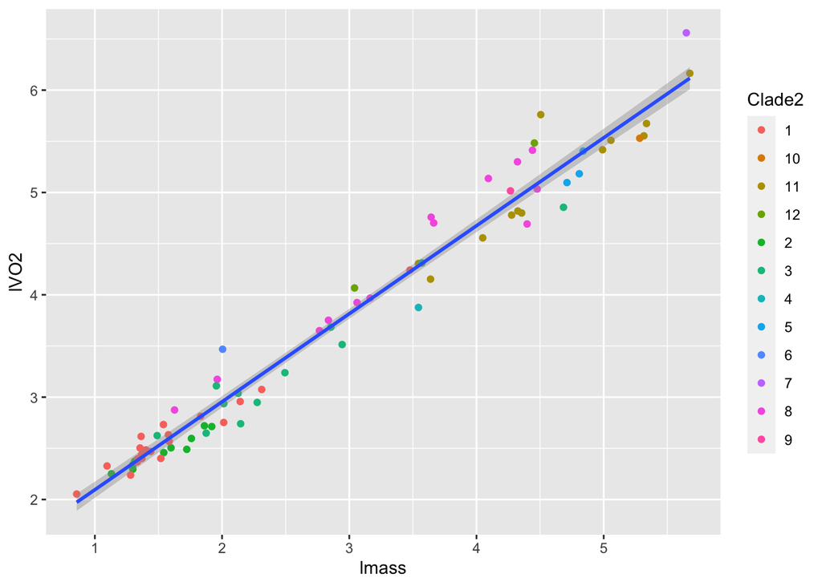

```r
ggplot(data = df, aes(x = lmass, y=lVO2)) +
  geom_point(aes(colour = Clade2))+
  geom_smooth(method = lm)
```

Giosa, Mammides, and Zotos (2018) is OK - model comparison, though it’s another biological survey data set, of which we have quite a few.

Schmidt and Drake (2011) is an example of boosted regression trees that might work if we want to go down that path.

## References

Dlugosz, Elizabeth M., Mark A. Chappell, Thomas H. Meek, Paulina Szafrańska, Karol Zub, Marek Konarzewski, James H. Jones, et al. 2013. “Phylogenetic Analysis of Mammalian Maximal Oxygen Consumption During Exercise.” *Journal of Experimental Biology*. https://doi.org/10.1242/jeb.088914.

Giosa, Efthymia, Christos Mammides, and Savvas Zotos. 2018. “The Importance of Artificial Wetlands for Birds: A Case Study from Cyprus.” *Plos One* 13 (5). https://doi.org/10.1371/journal.pone.0197286.

La Rosa, Raffica J., and Jeffrey K. Conner. 2017. “Floral Function: Effects of Traits on Pollinators, Male and Female Pollination Success, and Female Fitness Across Three Species of Milkweeds ( Asclepias ).” *American Journal of Botany* 104 (1): 150–60. https://doi.org/gr2r9p.

Schmidt, John Paul, and John M. Drake. 2011. “Time Since Introduction, Seed Mass, and Genome Size Predict Successful Invaders Among the Cultivated Vascular Plants of Hawaii.” *PLoS ONE* 6 (3). https://doi.org/bb2hs7.